# Unit 7 - Forecasting

# For Live Session

```r
library(tidyverse)
library(tswge)
```

## Question 1

1. Which model do you think is appropriate to use to forecast your time series? Why? Add this to the Google Doc as well as to your PowerPoint deck.

```r
df_train <- read.csv(file="../../Unit 2/pre_live/data/train.csv", header = TRUE)

# df_train$datetime = as.POSIXct(df_train$datetime)

df_train$datetime = as.POSIXct(strptime(df_train$datetime, "%Y-%m-%d %H:%M:%S"))


df_train <- df_train %>%
  mutate(year = as.factor(format(datetime, format = "%Y")),
         month = as.numeric(format(datetime, format = "%m")),
         day = as.factor(format(datetime, format = "%d")),
         hour = as.factor(format(datetime, format = "%H")))
```

```r
df_dec_2012 <- df_train %>%
    filter(datetime >= "2012-12-01")
```

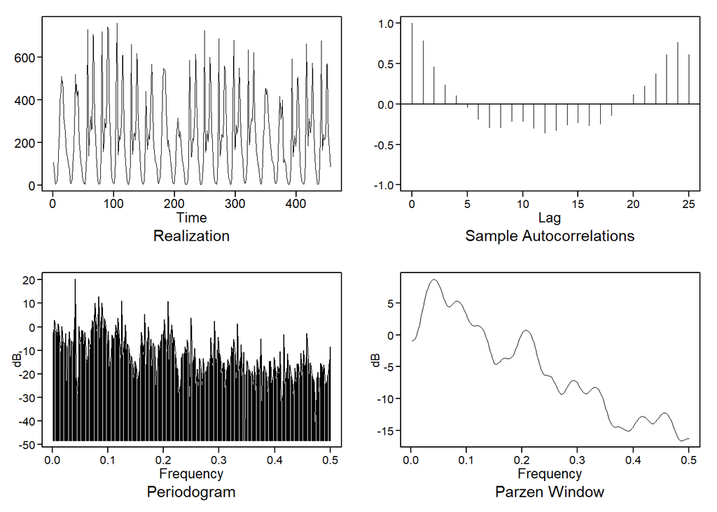

```
## $autplt
##  [1]  1.00000000  0.78368354  0.45885186  0.23969352  0.10202963 -0.03737585
##  [7] -0.18498628 -0.28841878 -0.28871506 -0.21038805 -0.21298191 -0.29600792
## [13] -0.35538064 -0.32627633 -0.25800737 -0.23330313 -0.26598658 -0.24437461
## [19] -0.13896279 -0.00118422  0.12117419  0.22067852  0.37509331  0.61064589
## [25]  0.76635039  0.61347715
##
## $freq
##   [1] 0.002192982 0.004385965 0.006578947 0.008771930 0.010964912 0.013157895
##   [7] 0.015350877 0.017543860 0.019736842 0.021929825 0.024122807 0.026315789
##  [13] 0.028508772 0.030701754 0.032894737 0.035087719 0.037280702 0.039473684
##  [19] 0.041666667 0.043859649 0.046052632 0.048245614 0.050438596 0.052631579
##  [25] 0.054824561 0.057017544 0.059210526 0.061403509 0.063596491 0.065789474
##  [31] 0.067982456 0.070175439 0.072368421 0.074561404 0.076754386 0.078947368
##  [37] 0.081140351 0.083333333 0.085526316 0.087719298 0.089912281 0.092105263
```

[output cut: 127 more lines]

```r
plotts.sample.wge(df_dec_2012$count)
```

```r
parzen.wge(df_dec_2012$count)
```

```
## $freq
##   [1] 0.002192982 0.004385965 0.006578947 0.008771930 0.010964912 0.013157895
##   [7] 0.015350877 0.017543860 0.019736842 0.021929825 0.024122807 0.026315789
##  [13] 0.028508772 0.030701754 0.032894737 0.035087719 0.037280702 0.039473684
##  [19] 0.041666667 0.043859649 0.046052632 0.048245614 0.050438596 0.052631579
##  [25] 0.054824561 0.057017544 0.059210526 0.061403509 0.063596491 0.065789474
##  [31] 0.067982456 0.070175439 0.072368421 0.074561404 0.076754386 0.078947368
##  [37] 0.081140351 0.083333333 0.085526316 0.087719298 0.089912281 0.092105263
##  [43] 0.094298246 0.096491228 0.098684211 0.100877193 0.103070175 0.105263158
##  [49] 0.107456140 0.109649123 0.111842105 0.114035088 0.116228070 0.118421053
##  [55] 0.120614035 0.122807018 0.125000000 0.127192982 0.129385965 0.131578947
##  [61] 0.133771930 0.135964912 0.138157895 0.140350877 0.142543860 0.144736842
##  [67] 0.146929825 0.149122807 0.151315789 0.153508772 0.155701754 0.157894737
##  [73] 0.160087719 0.162280702 0.164473684 0.166666667 0.168859649 0.171052632
##  [79] 0.173245614 0.175438596 0.177631579 0.179824561 0.182017544 0.184210526
```

[output cut: 72 more lines]

```r
bike_diff = artrans.wge(df_dec_2012$count, c(rep(0,23), 1))  # Take out the (1-B^24)
```

[figure not shown]

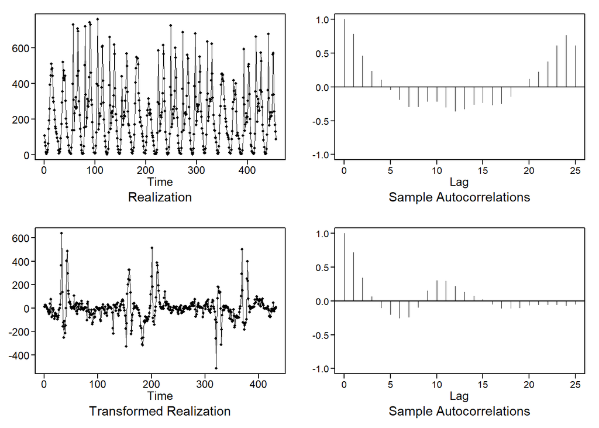

```r
aic5.wge(bike_diff) # Check the structure of the noise
```

```
## ---------WORKING... PLEASE WAIT...
##
##
## Five Smallest Values of  aic
```

|  | p | q | aic |
| --- | --- | --- | --- |
| 15 | 4 | 2 | 8.527084 |
| 9 | 2 | 2 | 8.584657 |
| 16 | 5 | 0 | 8.584838 |
| 14 | 4 | 1 | 8.585353 |
| 7 | 2 | 0 | 8.585361 |

```r
parzen.wge(bike_diff)
```

```
## $freq
##   [1] 0.002314815 0.004629630 0.006944444 0.009259259 0.011574074 0.013888889
##   [7] 0.016203704 0.018518519 0.020833333 0.023148148 0.025462963 0.027777778
##  [13] 0.030092593 0.032407407 0.034722222 0.037037037 0.039351852 0.041666667
##  [19] 0.043981481 0.046296296 0.048611111 0.050925926 0.053240741 0.055555556
##  [25] 0.057870370 0.060185185 0.062500000 0.064814815 0.067129630 0.069444444
##  [31] 0.071759259 0.074074074 0.076388889 0.078703704 0.081018519 0.083333333
##  [37] 0.085648148 0.087962963 0.090277778 0.092592593 0.094907407 0.097222222
##  [43] 0.099537037 0.101851852 0.104166667 0.106481481 0.108796296 0.111111111
##  [49] 0.113425926 0.115740741 0.118055556 0.120370370 0.122685185 0.125000000
##  [55] 0.127314815 0.129629630 0.131944444 0.134259259 0.136574074 0.138888889
##  [61] 0.141203704 0.143518519 0.145833333 0.148148148 0.150462963 0.152777778
##  [67] 0.155092593 0.157407407 0.159722222 0.162037037 0.164351852 0.166666667
##  [73] 0.168981481 0.171296296 0.173611111 0.175925926 0.178240741 0.180555556
##  [79] 0.182870370 0.185185185 0.187500000 0.189814815 0.192129630 0.194444444
```

[output cut: 68 more lines]

[figure not shown]

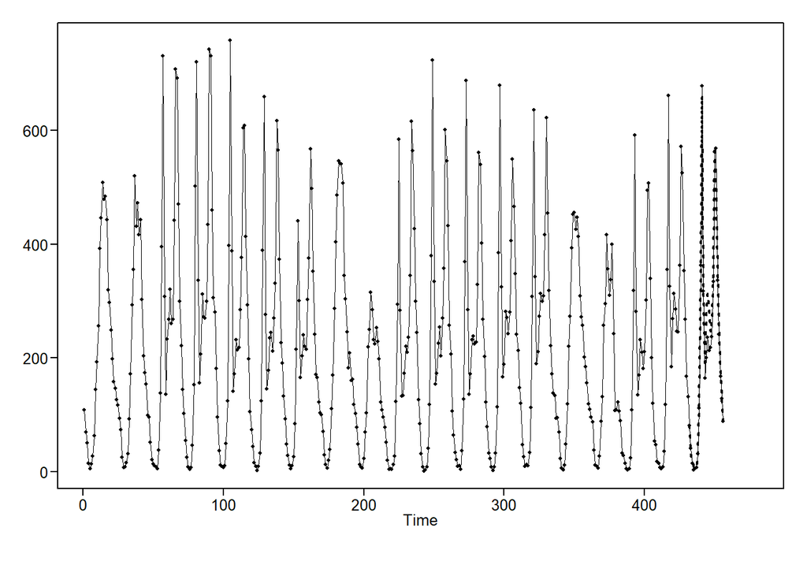

```r
bike = fore.aruma.wge(df_dec_2012$count, phi = c(.4), d = 0, s = 24, n.ahead = 24, lastn = TRUE, plot = TRUE, limits = FALSE)
```

```r
bike_ase = mean((df_dec_2012$count[(456 - 24 + 1): 456] - bike$f)^2)
bike_ase
```

```
## [1] 913.1819
```

## Question 2

Hint: equations to help find sigma_hat_A and the formula for the confidence prediction interval can be found on pages 245 and 246

$$\begin{equation}
(1 - .9B)(1 - .8B)X_{t} = a_{t}
\end{equation}$$

$$\begin{equation}
(1 - 1.7B + .72B^2)X_{t} = a_{t}
\end{equation}$$

First 8 Observations:

X_1 = 5 X_2 = 8 X_3 = 9 X_4 = 8 X_5 = 7 X_6 = 6 X_7 = 4 X_8 = 3

```r
# (1 - .9B)(1 - .8B)X_t = a_t

factor.wge(c(1.7, -.72))
```

```
##
## Coefficients of Original polynomial:
## 1.7000 -0.7200
##
## Factor                 Roots                Abs Recip    System Freq
## 1-0.9000B              1.1111               0.9000       0.0000
## 1-0.8000B              1.2500               0.8000       0.0000
##
##
```

```r
psi.weights.wge(phi = c(1.7, -.72), lag.max = 5)
```

```
## [1] 1.70000 2.17000 2.46500 2.62810 2.69297
```

```r
X_1 = 5
X_2 = 8
X_3 = 9
X_4 = 8
X_5 = 7
X_6 = 6
X_7 = 4
X_8 = 3

sigma_hat = NA

psi_0 = 1
psi_1 = 1.70000
psi_2 = 2.17000
psi_3 = 2.46500
psi_4 = 2.62810
psi_5 = 2.69297


l_1 = (1.96) * (sigma_hat) * psi_0
l_1
```

```
## [1] NA
```

```r
l_2 = (1.96) * (sigma_hat) * sqrt(1 + psi_1^2)
l_2
```

```
## [1] NA
```

```r
l_3 = (1.96) * (sigma_hat) * sqrt(1 + psi_1^2 + psi_2^2)
l_3
```

```
## [1] NA
```

## Question 3

3. Using the three models below and the Amtrak ridership data, which model has the smallest ASE in forecasting the next year (12 months)? Show your code in forecasting the 12 observations as well as in calculating the ASE.

**Model 1**

```r
df_amtrac <- read.csv(file="../AmtrakPassengersMonthly.csv", header = TRUE)

model1 = fore.aruma.wge(df_amtrac$Ridership, d = 0, s = 0, phi = c(0.5511, 0.1680, -0.0145, 0.0651, 0.1388, -0.2966, 0.1539, 0.1270, -0.1815, 0.0364, 0.1456, 0.6287, -0.3832, -0.0199, -0.1679), n.ahead = 12, lastn = TRUE, limits = FALSE)
```

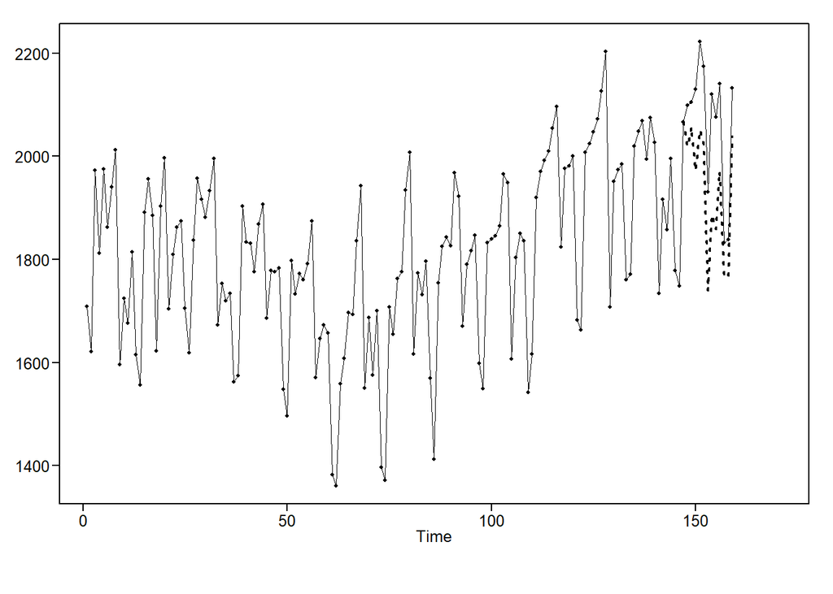

```r
model1_ase = mean((df_amtrac$Ridership[(159 - 12 + 1): 159] - model1$f)^2)
model1_ase
```

```
## [1] 22588.56
```

**Model 2**

phis: c(-0.02709541, 0.74213105) thetas: c(-0.5844596, 0.3836931)

```r
model2 = fore.aruma.wge(df_amtrac$Ridership, d = 0, s = 12, phi = c(-0.02709541,  0.74213105), theta = c(-0.5844596,  0.3836931), n.ahead = 12, lastn = TRUE, limits = FALSE)
```

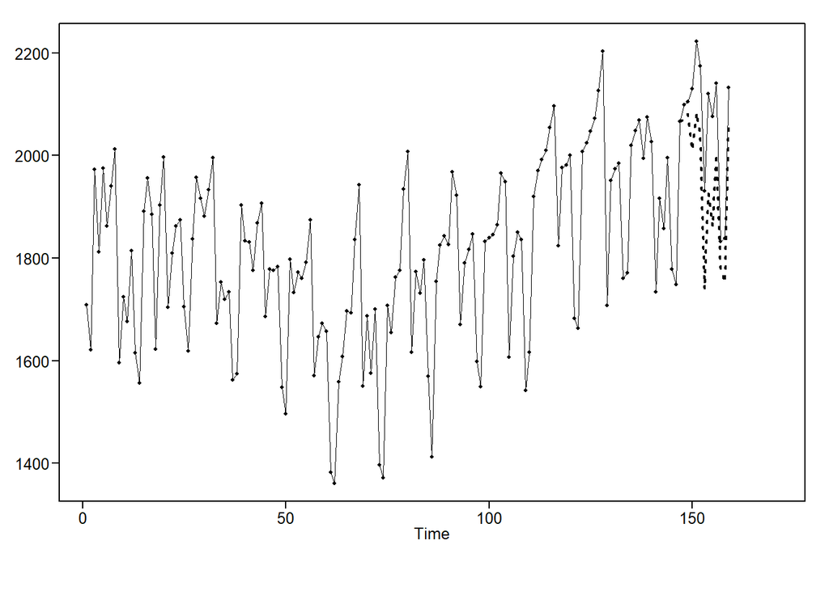

```r
model2_ase = mean((df_amtrac$Ridership[(159 - 12 + 1): 159] - model2$f)^2)
model2_ase
```

```
## [1] 17197.77
```

**Model 3**

(1 − .3069𝐵)(1−𝐵)(1−𝐵^12)𝑋_𝑡=〖(1“−” 0.7432𝐵)𝑎〗_𝑡

phi: 0.306943 theta: 0.7431719

```r
model3 = fore.aruma.wge(df_amtrac$Ridership, d = 1, s = 12, phi = 0.306943, theta = 0.7431719, n.ahead = 12, lastn = TRUE, limits = FALSE)
```

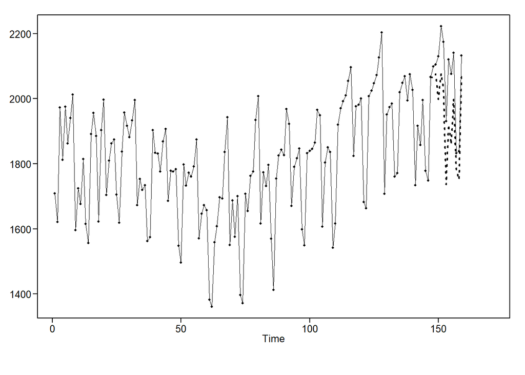

```r
model3_ase = mean((df_amtrac$Ridership[(159 - 12 + 1): 159] - model3$f)^2)
model3_ase
```

```
## [1] 18399.97
```

# Asynchronous Material

## 7.4 Forecasting with AR(p) Models

### AR(1)

forecasts tend to approach the sample mean

```r
# (1 - 8B)(X_t - 25) = a_t

X_80 = 21.77
X_bar = 24.17

X_80_1 = 22.25
X_80_2 = 22.63
X_80_3 = 22.93

# X_t = **(1 - .8)mu** + .8X_t-1 + a_t

const = (1 - .8) * (X_bar)
round(const, 2)
```

```
## [1] 4.83
```

```r
X_80_4 = round(const + .8 * (X_80_3), 2)
X_80_4
```

```
## [1] 23.18
```

```r
X_80_5 = round(const + .8 * (X_80_4), 2)
X_80_5
```

```
## [1] 23.38
```

```r
X_80_6 = round(const + .8 * (X_80_5), 2)
X_80_6
```

```
## [1] 23.54
```

### AR(2)

forecasts tend to gradually in a sinusoidal pattern come back to the mean

$$\begin{equation}
\hat {X_t}_0 (l) = \phi_1 \hat {X_t}_0 (l-1) + \phi_2 \hat {X_t}_0 (l-2) + \hat X(1 - \phi_1 - \phi_2)
\end{equation}$$

```r
# (1 - 1.6B + .8B^2)(X_t - 50) = a_t

X_75 = 23.4
X_74 = 27.7
X_bar = 29.4

# X_75_1 = 21.2
# X_75_2 = 21.1
# X_75_3 = 22.7

# X_bar(1 - phi1 - phi2)

phi1 = 1.6
phi2 = -.8

const = (X_bar) * (1 - phi1 - phi2)
round(const, 2)
```

```
## [1] 5.88
```

```r
X_75_1 = round( (1.6 * X_75) + (-.8 * X_74) + const, 2)
X_75_1 = 21.2

X_75_2 = round( (1.6 * X_75_1) + (-.8 * X_75) + const, 2)
X_75_2 = 21.1

X_75_3 = round( (1.6 * X_75_2) + (-.8 * X_75_1) + const, 2)
X_75_3 = 22.7

X_75_4 = round( (1.6 * X_75_3) + (-.8 * X_75_2) + const, 1)
X_75_4
```

```
## [1] 25.3
```

```r
X_75_5 = round( (1.6 * X_75_4) + (-.8 * X_75_3) + const, 1)
X_75_5
```

```
## [1] 28.2
```

```r
X_75_6 = round( (1.6 * X_75_5) + (-.8 * X_75_4) + const, 1)
X_75_6
```

```
## [1] 30.8
```

### TSWGE

#### AR(1) Phi Positive

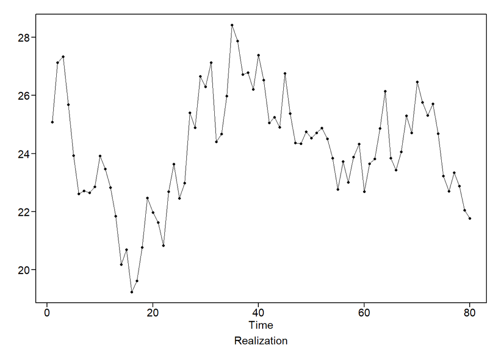

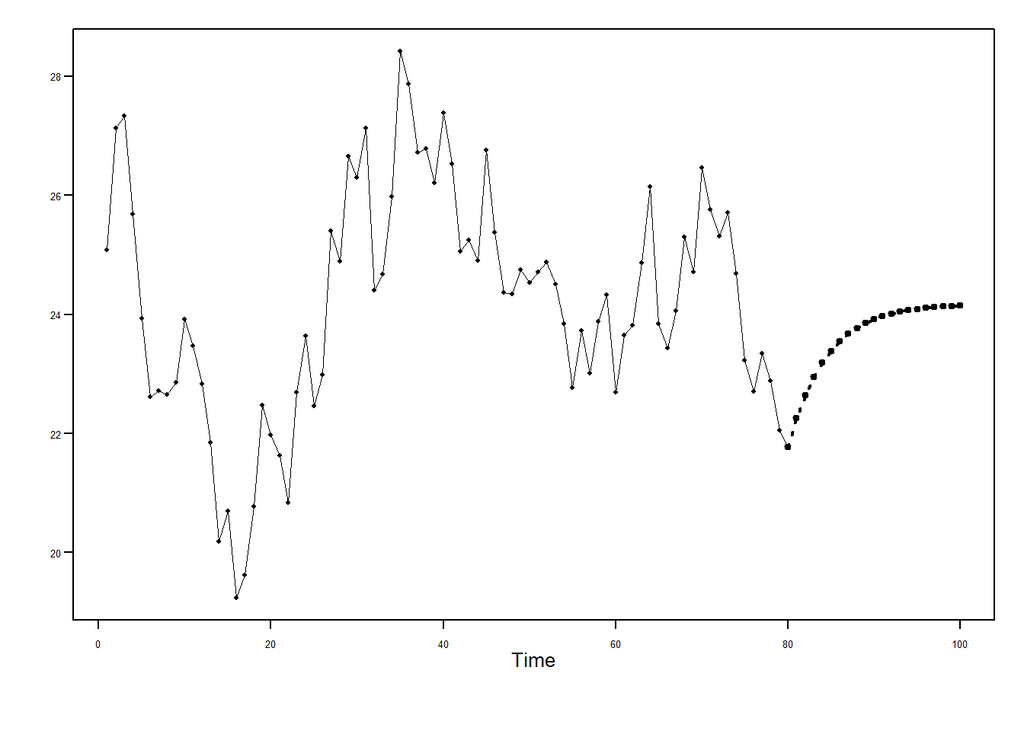

#### AR(1) Phi Negative

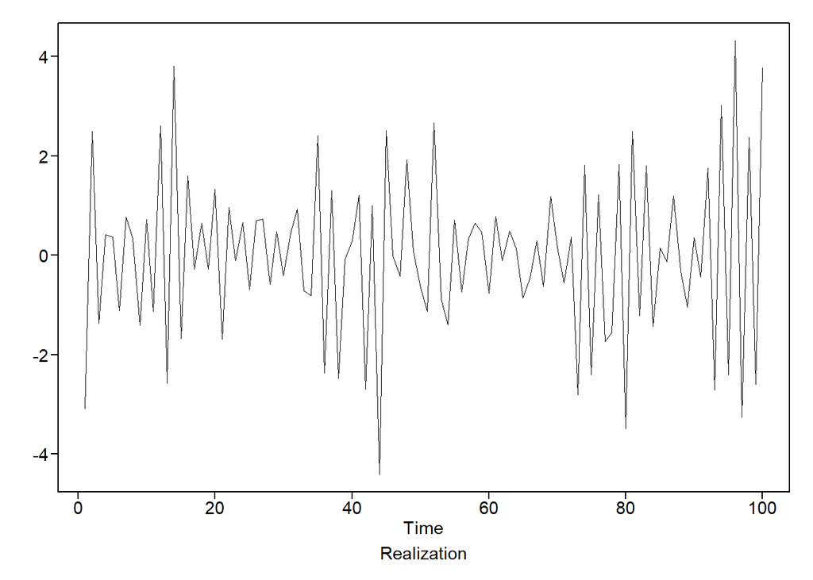

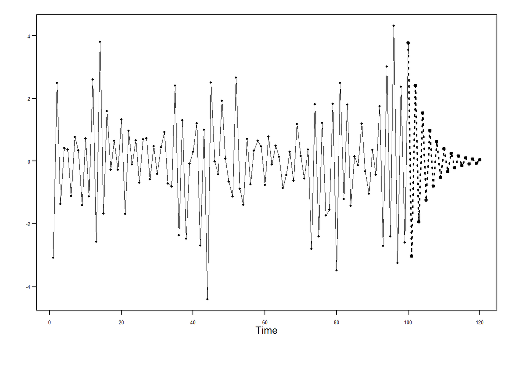

#### AR(2)

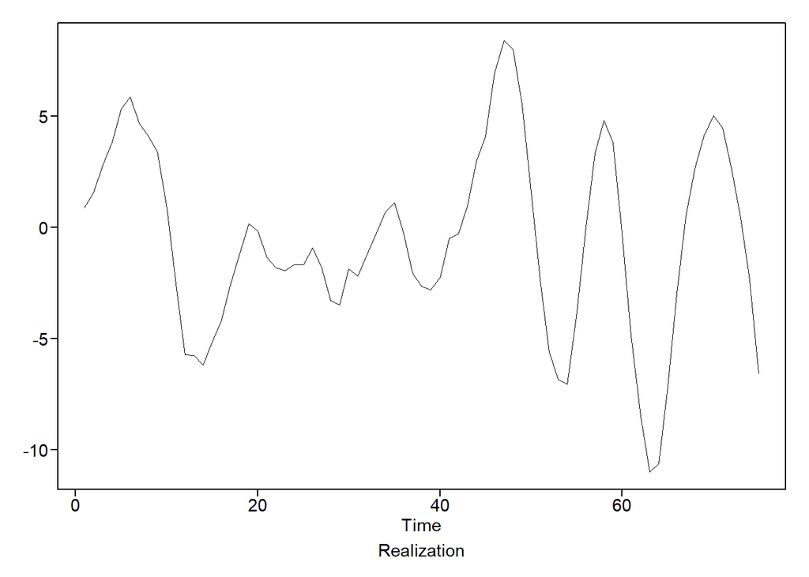

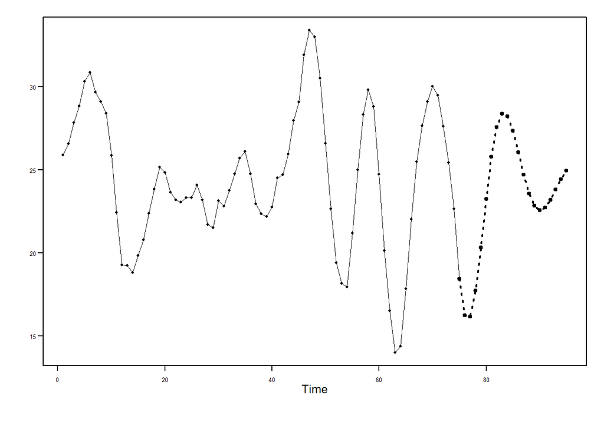

### Eventual Forecast Function

Key Observations

1. In both cases, the forecasts behave like the auto correlations.
- AR(1) case: forecasts have exponential shape (although increasing instead of decreasing)
- AR(2) case: forecasts look like a damped sinusoid (AR part has complex conjugate roots)
2. The forecasts tend toward teh realization mean as number of steps ahead increases.

## 7.5 Forecasting with ARMA(p,q)

### Example

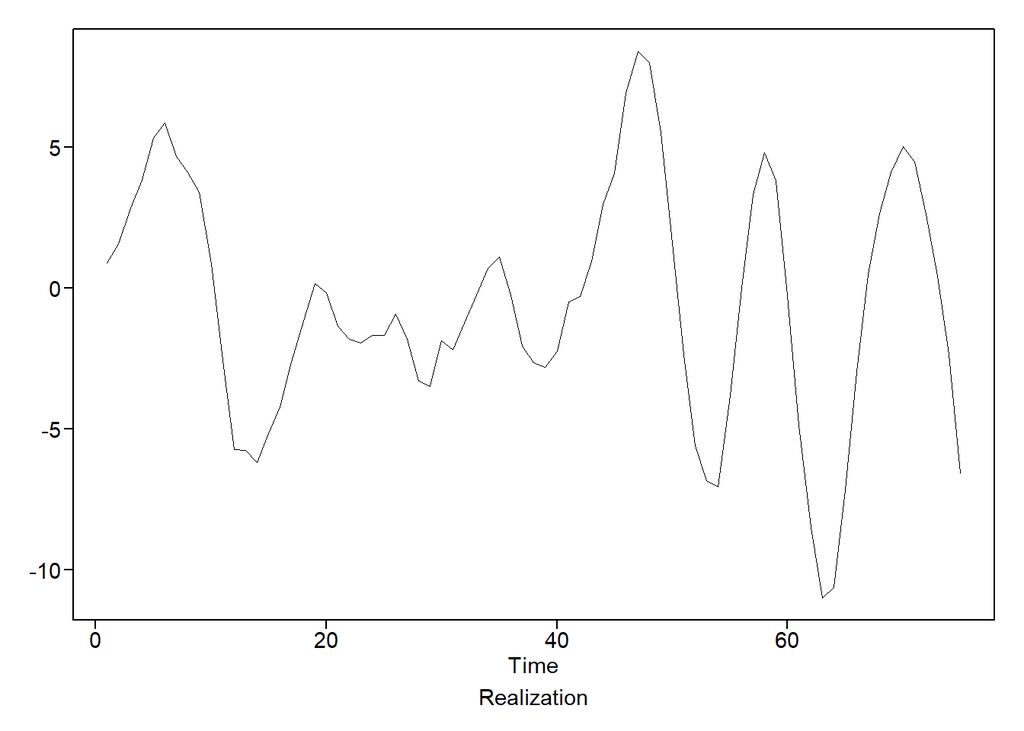

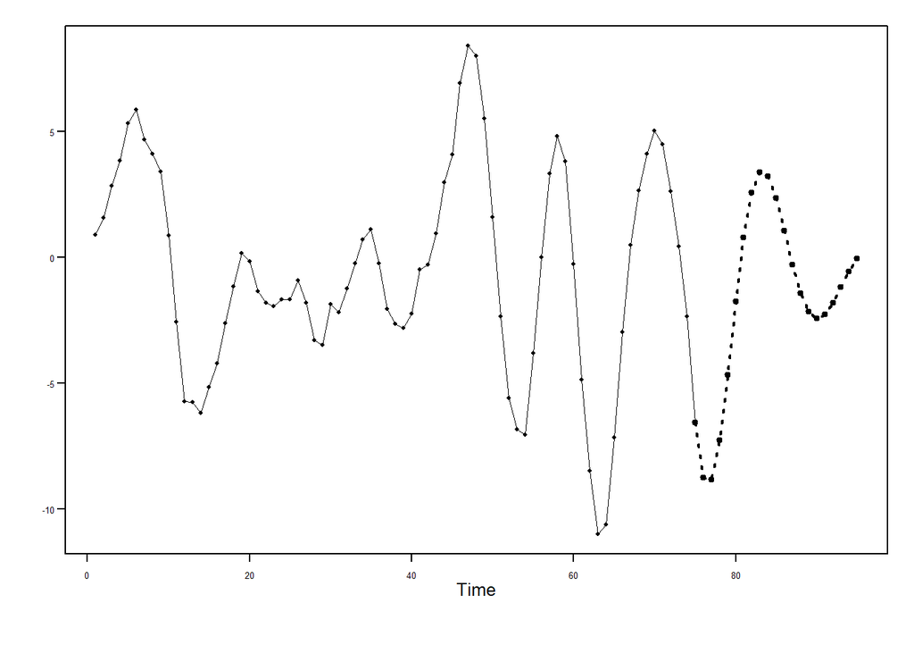

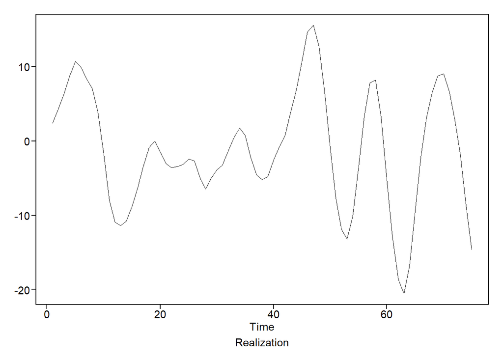

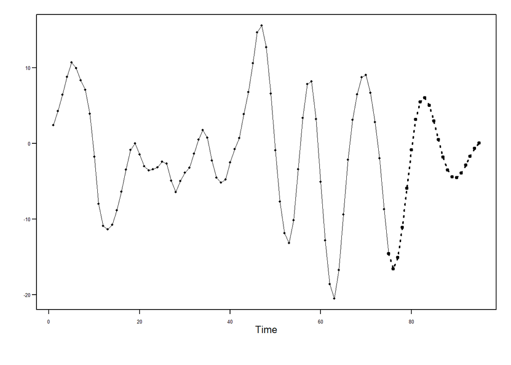

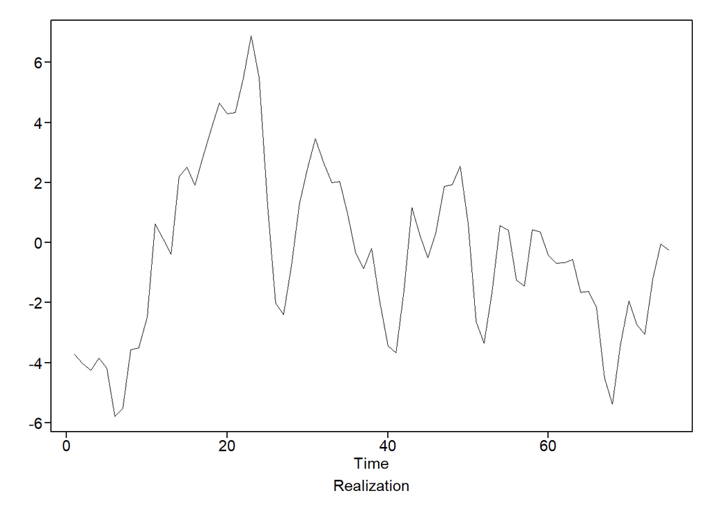

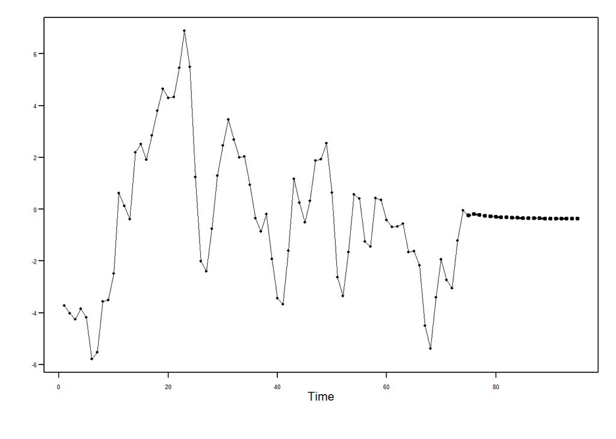

### Canadian Lynx Data

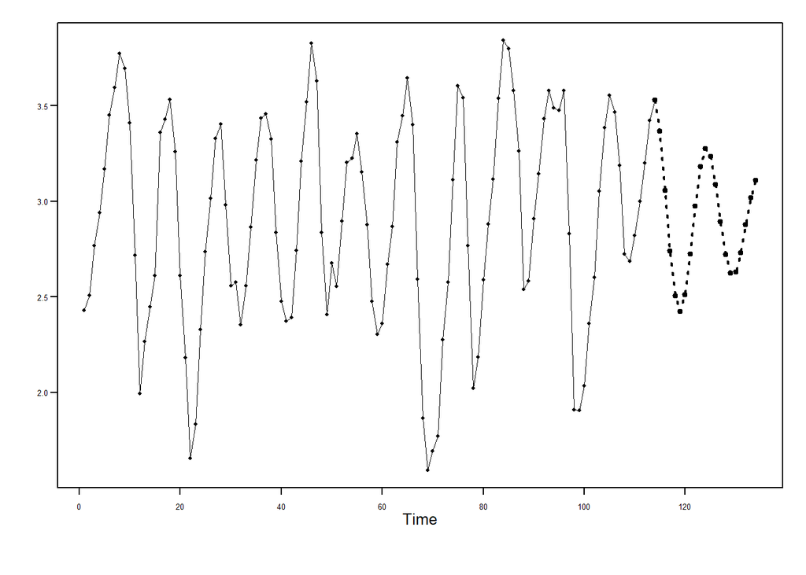

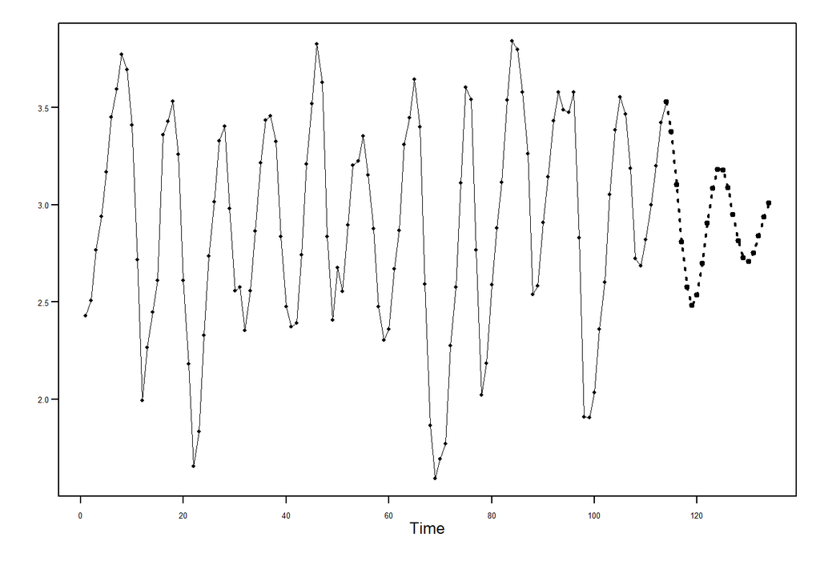

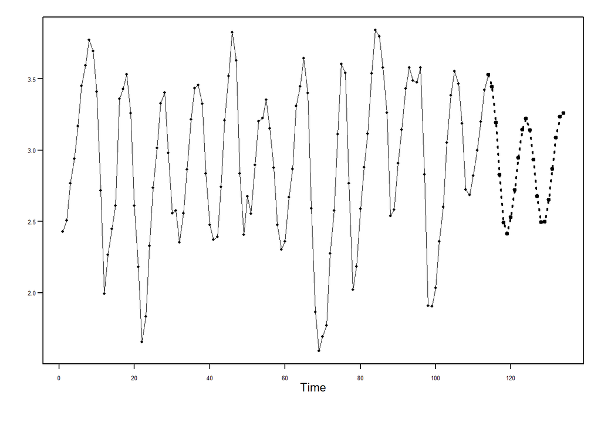